# Lab12_JohnBauer

John Bauer

2024-04-12

```r
library(tidyverse)
library(knitr)
```

```r
NEON_MAGs <- read_csv("~/Bio 676/Lab12/data/GOLD_Study_ID_Gs0161344_NEON_2024_4_21.csv") %>%
  # remove columns that are not needed for data analysis
  select(-c(`GOLD Study ID`, `Bin Methods`, `Created By`, `Date Added`)) %>%
  # create a new column with the Assembly Type
  mutate("Assembly Type" = case_when(`Genome Name` == "NEON combined assembly" ~ `Genome Name`,
                            TRUE ~ "Individual")) %>%
  mutate_at("Assembly Type", str_replace, "NEON combined assembly", "Combined") %>%
  separate(`GTDB-Tk Taxonomy Lineage`, c("Domain", "Phylum", "Class", "Order", "Family", "Genus"), "; ", remove = FALSE) %>%
  # Get rid of the the common string "Soil microbial communities from "
  mutate_at("Genome Name", str_replace, "Terrestrial soil microbial communities from ", "") %>%
  # Use the first `-` to split the column in two
  separate(`Genome Name`, c("Site","Sample Name"), " - ") %>%
  # Get rid of the the common string "S-comp-1"
  mutate_at("Sample Name", str_replace, "-comp-1", "") %>%
  # separate the Sample Name into Site ID and plot info
  separate(`Sample Name`, c("Site ID","subplot.layer.date"), "_", remove = FALSE,) %>%
  # separate the plot info into 3 columns
  separate(`subplot.layer.date`, c("Subplot", "Layer", "Date"), "-")
NEON_metagenomes <- read_tsv("~/Bio 676/Lab12/data/exported_img_data_Gs0161344_NEON.tsv") %>%
  rename(`Genome Name` = `Genome Name / Sample Name`) %>%
  filter(str_detect(`Genome Name`, 're-annotation', negate = T)) %>%
  filter(str_detect(`Genome Name`, 'WREF plot', negate = T))
NEON_metagenomes <- NEON_metagenomes %>%
  # Get rid of the the common string "Soil microbial communities from "
  mutate_at("Genome Name", str_replace, "Terrestrial soil microbial communities from ", "") %>%
  # Use the first `-` to split the column in two
  separate(`Genome Name`, c("Site","Sample Name"), " - ") %>%
  # Get rid of the the common string "-comp-1"
  mutate_at("Sample Name", str_replace, "-comp-1", "") %>%
  # separate the Sample Name into Site ID and plot info
  separate(`Sample Name`, c("Site ID","subplot.layer.date"), "_", remove = FALSE,) %>%
  # separate the plot info into 3 columns
  separate(`subplot.layer.date`, c("Subplot", "Layer", "Date"), "-")
NEON_chemistry <- read_tsv("~/Bio 676/Lab12/data/neon_plot_soilChem1_metadata.tsv") %>%
  # remove -COMP from genomicsSampleID
  mutate_at("genomicsSampleID", str_replace, "-COMP", "")
kable(
  NEON_chemistry_description <- read_tsv("~/Bio 676/Lab12/data/neon_soilChem1_metadata_descriptions.tsv")
)
```

| fieldName | description | dataType | units |
| --- | --- | --- | --- |
| siteID | NEON site code | string | NA |
| plotID | Plot identifier (NEON site code_XXX) | string | NA |
| sampleID | Identifier for sample | string | NA |
| horizon | Organic or mineral soil | string | NA |
| genomicsSampleID | Identifier for a genomics sample | string | NA |
| d15N | Measure of the ratio of 15N:14N in a sample, relative to atmospheric N2 | real | permill |
| organicd13C | Measure of the ratio of 13C:12C in soil organic carbon, relative to Vienna Pee Dee Belemnite | real | permill |
| nitrogenPercent | Percent nitrogen in a sample on a dry weight basis | real | percent |
| organicCPercent | Percent organic carbon in a sample on a dry weight basis | real | percent |
| CNratio | Ratio of carbon to nitrogen concentration in a sample on a dry weight basis | real | NA |
| nlcdClass | National Land Cover Database Vegetation Type Name | string | NA |
| subplotID | Identifier for the NEON subplot | string | NA |
| coreCoordinateX | x location of the soil core relative to the SW corner | real | meter |
| coreCoordinateY | y location of the soil core relative to the SW corner | real | meter |
| decimalLatitude | The geographic latitude (in decimal degrees, WGS84) of the geographic center of the reference area | real | decimalDegree |
| decimalLongitude | The geographic longitude (in decimal degrees, WGS84) of the geographic center of the reference area | real | decimalDegree |
| elevation | Elevation (in meters) above sea level | real | meter |
| sampleTiming | Timing of the sampling event with regard to the field season | string | NA |
| soilTemp | In-situ temperature of soil at approximately 10 cm depth | real | degree |
| sampleTopDepth | Depth below the soil surface of the top of a soil sample | real | centimeter |
| sampleBottomDepth | Depth below the soil surface of the bottom of a soil sample | real | centimeter |
| soilInWaterpH | pH value of soil measured in water solution | real | pH |
| soilInCaClpH | pH value of soil measured in calcium chloride solution | real | pH |

# Excerises

## Tidyverse Excercises

```r
band_members
```

```
## # A tibble: 3 × 2
##   name  band
##   <chr> <chr>
## 1 Mick  Stones
## 2 John  Beatles
## 3 Paul  Beatles
```

```r
band_instruments
```

```
## # A tibble: 3 × 2
##   name  plays
##   <chr> <chr>
## 1 John  guitar
## 2 Paul  bass
## 3 Keith guitar
```

```r
# drops any row in the second data set that does not match a row in the first data set.
band_members %>%
  left_join(band_instruments, by="name")
```

```
## # A tibble: 3 × 3
##   name  band    plays
##   <chr> <chr>   <chr>
## 1 Mick  Stones  <NA>
## 2 John  Beatles guitar
## 3 Paul  Beatles bass
```

```r
# drops any row in the first data set that does not match a row in the second data set.
band_members %>%
  right_join(band_instruments, by="name")
```

```
## # A tibble: 3 × 3
##   name  band    plays
##   <chr> <chr>   <chr>
## 1 John  Beatles guitar
## 2 Paul  Beatles bass
## 3 Keith <NA>    guitar
```

```r
#drops any row in either data set that does not have a match in both data sets
band_members %>%
  inner_join(band_instruments, by="name")
```

```
## # A tibble: 2 × 3
##   name  band    plays
##   <chr> <chr>   <chr>
## 1 John  Beatles guitar
## 2 Paul  Beatles bass
```

```r
#retains every row from both data sets; it is the only join guaranteed to retain all of the original data
band_members %>%
  full_join(band_instruments, by="name")
```

```
## # A tibble: 4 × 3
##   name  band    plays
##   <chr> <chr>   <chr>
## 1 Mick  Stones  <NA>
## 2 John  Beatles guitar
## 3 Paul  Beatles bass
## 4 Keith <NA>    guitar
```

```r
#join by two specified columns
table1 %>%
  left_join(table3, by = c("country", "year"))
```

```
## # A tibble: 6 × 5
##   country      year  cases population rate
##   <chr>       <dbl>  <dbl>      <dbl> <chr>
## 1 Afghanistan  1999    745   19987071 745/19987071
## 2 Afghanistan  2000   2666   20595360 2666/20595360
## 3 Brazil       1999  37737  172006362 37737/172006362
## 4 Brazil       2000  80488  174504898 80488/174504898
## 5 China        1999 212258 1272915272 212258/1272915272
## 6 China        2000 213766 1280428583 213766/1280428583
```

```r
#join by columns with different names
#For each element,
#    Write the name of the column that appears in the first data frame
#    Write an equals sign
#    Write the name of the matching column that appears in the second data set.
band_members %>%
  left_join(band_instruments2, by = c(name = "artist"))
```

```
## # A tibble: 3 × 3
##   name  band    plays
##   <chr> <chr>   <chr>
## 1 Mick  Stones  <NA>
## 2 John  Beatles guitar
## 3 Paul  Beatles bass
```

```r
#tables with multiple same name columns that were not joined on will be labeled x,y
table4a %>%
  left_join(table4b, by = "country")
```

```
## # A tibble: 3 × 5
##   country     `1999.x` `2000.x`   `1999.y`   `2000.y`
##   <chr>          <dbl>    <dbl>      <dbl>      <dbl>
## 1 Afghanistan      745     2666   19987071   20595360
## 2 Brazil         37737    80488  172006362  174504898
## 3 China         212258   213766 1272915272 1280428583
```

```r
# set suffix
table4a %>%
  left_join(table4b, by = "country", suffix = c("_cases", "_pop"))
```

```
## # A tibble: 3 × 5
##   country     `1999_cases` `2000_cases` `1999_pop` `2000_pop`
##   <chr>              <dbl>        <dbl>      <dbl>      <dbl>
## 1 Afghanistan          745         2666   19987071   20595360
## 2 Brazil             37737        80488  172006362  174504898
## 3 China             212258       213766 1272915272 1280428583
```

## Exercise 1

Create some tables with just a few columns to work on the basics of table joins by making a new data frame selecting In NEON_MAGs the columns Sample Name, Site ID, GTDB-Tk Taxonomy Lineage In NEON_metagenomes the columns Sample Name, Site ID, Ecosystem Subtype In NEON_chemistry the columns genomicsSampleID, siteID, nlcdClass

```r
#In NEON_MAGs the columns Sample Name, Site ID, GTDB-Tk Taxonomy Lineage
NEON_MAGs_Short <- NEON_MAGs %>%
  select(c(`Sample Name`,`Site ID`,`GTDB-Tk Taxonomy Lineage`))
#In NEON_metagenomes the columns Sample Name, Site ID, Ecosystem Subtype
NEON_metagenomes_Short <- NEON_metagenomes %>%
  select(c(`Sample Name`, `Site ID`, `Ecosystem Subtype`))
#In NEON_chemistry the columns genomicsSampleID, siteID, nlcdClass
NEON_chemistry_Short <- NEON_chemistry %>%
  select(c(`genomicsSampleID`, `siteID`, `nlcdClass`))
```

## Excercise 2

Now filter the above NEON_MAGs, NEON_metagenomes and NEON_chemistry to contain just the data for your project site

```r
NEON_MAGs_Short_TOOL <-NEON_MAGs_Short %>%
  filter(str_detect(`Site ID`,"TOOL"))
NEON_metagenomes_Short_TOOL <-NEON_metagenomes_Short %>%
  filter(str_detect(`Site ID`,"TOOL"))
NEON_chemistry_Short_TOOL <-NEON_chemistry_Short %>%
  filter(str_detect(`siteID`,"TOOL"))
```

## Excercise 3

Do a left join of the NEON MAGs with NEON metagenomes by the Sample Name and show the resulting table. Notice what happens when 2 columns have the same name. Did you get the number of rows you expected?

```r
NEON_MAGs_Short %>%
  left_join(NEON_metagenomes_Short, by="Sample Name" )
```

```
## # A tibble: 1,754 × 5
##    `Sample Name`       `Site ID.x` `GTDB-Tk Taxonomy Lineage`    Site …¹ Ecosy…²
##    <chr>               <chr>       <chr>                         <chr>   <chr>
##  1 CLBJ_001-M-20210506 CLBJ        d__Bacteria;p__Acidobacterio… CLBJ    Grassl…
##  2 CLBJ_001-M-20210506 CLBJ        d__Bacteria;p__Acidobacterio… CLBJ    Grassl…
##  3 CLBJ_001-M-20210506 CLBJ        d__Bacteria;p__Actinomycetot… CLBJ    Grassl…
##  4 CLBJ_001-M-20210506 CLBJ        d__Bacteria;p__Actinomycetot… CLBJ    Grassl…
##  5 CLBJ_001-M-20210506 CLBJ        d__Bacteria;p__Pseudomonadot… CLBJ    Grassl…
##  6 CLBJ_001-M-20210506 CLBJ        d__Bacteria;p__Acidobacterio… CLBJ    Grassl…
##  7 CLBJ_001-M-20210506 CLBJ        d__Bacteria;p__Chloroflexota… CLBJ    Grassl…
##  8 CLBJ_001-M-20210506 CLBJ        d__Bacteria;p__Acidobacterio… CLBJ    Grassl…
##  9 BONA_009-O-20210707 BONA        d__Bacteria;p__Actinomycetot… BONA    Boreal…
## 10 BONA_009-O-20210707 BONA        d__Bacteria;p__Acidobacterio… BONA    Boreal…
## # … with 1,744 more rows, and abbreviated variable names ¹`Site ID.y`,
## #   ²`Ecosystem Subtype`
```

## Exercise 4

Using the data from your site do a left join of the NEON chemistry with NEON metagenomes from above by the Sample Name and genomicsSampleID columns and show the resulting table. Use by = c(“Sample Name” = “genomicsSampleID”)). Did you get the number of rows you expected?

```r
NEON_metagenomes_Short_TOOL %>%
  left_join(NEON_chemistry_Short_TOOL,by = c("Sample Name" = "genomicsSampleID"))
```

```
## # A tibble: 9 × 5
##   `Sample Name`       `Site ID` `Ecosystem Subtype` siteID nlcdClass
##   <chr>               <chr>     <chr>               <chr>  <chr>
## 1 TOOL_002-O-20210804 TOOL      Tundra              TOOL   dwarfScrub
## 2 TOOL_041-O-20210803 TOOL      Tundra              TOOL   sedgeHerbaceous
## 3 TOOL_003-O-20210805 TOOL      Tundra              TOOL   sedgeHerbaceous
## 4 TOOL_005-O-20210806 TOOL      Tundra              TOOL   dwarfScrub
## 5 TOOL_042-O-20210803 TOOL      Tundra              TOOL   sedgeHerbaceous
## 6 TOOL_006-O-20210804 TOOL      Tundra              TOOL   shrubScrub
## 7 TOOL_044-O-20210803 TOOL      Tundra              TOOL   sedgeHerbaceous
## 8 TOOL_004-O-20210805 TOOL      Tundra              TOOL   dwarfScrub
## 9 TOOL_043-O-20210803 TOOL      Tundra              TOOL   sedgeHerbaceous
```

## Exercise 5

Does it matter with these tables if your do a left, right or full join. Show the resulting tables

```r
NEON_metagenomes_Short_TOOL %>%
  left_join(NEON_chemistry_Short_TOOL,by = c("Sample Name" = "genomicsSampleID"))
```

```
## # A tibble: 9 × 5
##   `Sample Name`       `Site ID` `Ecosystem Subtype` siteID nlcdClass
##   <chr>               <chr>     <chr>               <chr>  <chr>
## 1 TOOL_002-O-20210804 TOOL      Tundra              TOOL   dwarfScrub
## 2 TOOL_041-O-20210803 TOOL      Tundra              TOOL   sedgeHerbaceous
## 3 TOOL_003-O-20210805 TOOL      Tundra              TOOL   sedgeHerbaceous
## 4 TOOL_005-O-20210806 TOOL      Tundra              TOOL   dwarfScrub
## 5 TOOL_042-O-20210803 TOOL      Tundra              TOOL   sedgeHerbaceous
## 6 TOOL_006-O-20210804 TOOL      Tundra              TOOL   shrubScrub
## 7 TOOL_044-O-20210803 TOOL      Tundra              TOOL   sedgeHerbaceous
## 8 TOOL_004-O-20210805 TOOL      Tundra              TOOL   dwarfScrub
## 9 TOOL_043-O-20210803 TOOL      Tundra              TOOL   sedgeHerbaceous
```

```r
NEON_metagenomes_Short_TOOL %>%
  right_join(NEON_chemistry_Short_TOOL,by = c("Sample Name" = "genomicsSampleID"))
```

```
## # A tibble: 9 × 5
##   `Sample Name`       `Site ID` `Ecosystem Subtype` siteID nlcdClass
##   <chr>               <chr>     <chr>               <chr>  <chr>
## 1 TOOL_002-O-20210804 TOOL      Tundra              TOOL   dwarfScrub
## 2 TOOL_041-O-20210803 TOOL      Tundra              TOOL   sedgeHerbaceous
## 3 TOOL_003-O-20210805 TOOL      Tundra              TOOL   sedgeHerbaceous
## 4 TOOL_005-O-20210806 TOOL      Tundra              TOOL   dwarfScrub
## 5 TOOL_042-O-20210803 TOOL      Tundra              TOOL   sedgeHerbaceous
## 6 TOOL_006-O-20210804 TOOL      Tundra              TOOL   shrubScrub
## 7 TOOL_044-O-20210803 TOOL      Tundra              TOOL   sedgeHerbaceous
## 8 TOOL_004-O-20210805 TOOL      Tundra              TOOL   dwarfScrub
## 9 TOOL_043-O-20210803 TOOL      Tundra              TOOL   sedgeHerbaceous
```

```r
NEON_metagenomes_Short_TOOL %>%
  full_join(NEON_chemistry_Short_TOOL,by = c("Sample Name" = "genomicsSampleID"))
```

```
## # A tibble: 9 × 5
##   `Sample Name`       `Site ID` `Ecosystem Subtype` siteID nlcdClass
##   <chr>               <chr>     <chr>               <chr>  <chr>
## 1 TOOL_002-O-20210804 TOOL      Tundra              TOOL   dwarfScrub
## 2 TOOL_041-O-20210803 TOOL      Tundra              TOOL   sedgeHerbaceous
## 3 TOOL_003-O-20210805 TOOL      Tundra              TOOL   sedgeHerbaceous
## 4 TOOL_005-O-20210806 TOOL      Tundra              TOOL   dwarfScrub
## 5 TOOL_042-O-20210803 TOOL      Tundra              TOOL   sedgeHerbaceous
## 6 TOOL_006-O-20210804 TOOL      Tundra              TOOL   shrubScrub
## 7 TOOL_044-O-20210803 TOOL      Tundra              TOOL   sedgeHerbaceous
## 8 TOOL_004-O-20210805 TOOL      Tundra              TOOL   dwarfScrub
## 9 TOOL_043-O-20210803 TOOL      Tundra              TOOL   sedgeHerbaceous
```

## Exercise 6

Do a left join of the NEON chemistry with NEON metagenomes by site ID columns and show the resulting table. Did you get the number of rows you expected?

```r
NEON_chemistry_Short %>%
  left_join(NEON_metagenomes_Short, by =c("siteID"="Site ID"))
```

```
## # A tibble: 635 × 5
##    genomicsSampleID    siteID nlcdClass       `Sample Name`       Ecosystem Su…¹
##    <chr>               <chr>  <chr>           <chr>               <chr>
##  1 GUAN_048-M-20210920 GUAN   evergreenForest GUAN_048-M-20210920 Tropical fore…
##  2 GUAN_048-M-20210920 GUAN   evergreenForest GUAN_042-M-20210920 Tropical fore…
##  3 GUAN_048-M-20210920 GUAN   evergreenForest GUAN_006-M-20210922 Tropical fore…
##  4 GUAN_048-M-20210920 GUAN   evergreenForest GUAN_003-M-20210922 Tropical fore…
##  5 GUAN_048-M-20210920 GUAN   evergreenForest GUAN_004-M-20210922 Tropical fore…
##  6 GUAN_048-M-20210920 GUAN   evergreenForest GUAN_043-M-20210921 Tropical fore…
##  7 GUAN_048-M-20210920 GUAN   evergreenForest GUAN_007-M-20210922 Tropical fore…
##  8 GUAN_042-M-20210920 GUAN   evergreenForest GUAN_048-M-20210920 Tropical fore…
##  9 GUAN_042-M-20210920 GUAN   evergreenForest GUAN_042-M-20210920 Tropical fore…
## 10 GUAN_042-M-20210920 GUAN   evergreenForest GUAN_006-M-20210922 Tropical fore…
## # … with 625 more rows, and abbreviated variable name ¹`Ecosystem Subtype`
```

## Exercise 7

Join the NEON MAG, metagenome and chemistry dataframes into a single data frame. What happens to the metagenome and chemistry information on the rows with the NEON coassembly?

Chemistry data for coassembly rows is largely left blank metagenome data is all the same for coassembly rows

```r
NEON_chemistry_7 <-NEON_chemistry %>%
  full_join(NEON_metagenomes, by =c("genomicsSampleID"="Sample Name")) %>%
  full_join(NEON_MAGs, by= c("genomicsSampleID"="Sample Name"))
NEON_chemistry_7
```

```
## # A tibble: 1,756 × 93
##    genomicsSa…¹ siteID plotID nlcdC…² decim…³ decim…⁴ eleva…⁵ collecti…⁶ horizon
##    <chr>        <chr>  <chr>  <chr>     <dbl>   <dbl>   <dbl> <date>     <chr>
##  1 GUAN_048-M-… GUAN   GUAN_… evergr…    18.0   -66.9    130. 2021-09-20 M
##  2 GUAN_048-M-… GUAN   GUAN_… evergr…    18.0   -66.9    130. 2021-09-20 M
##  3 GUAN_048-M-… GUAN   GUAN_… evergr…    18.0   -66.9    130. 2021-09-20 M
##  4 GUAN_048-M-… GUAN   GUAN_… evergr…    18.0   -66.9    130. 2021-09-20 M
##  5 GUAN_048-M-… GUAN   GUAN_… evergr…    18.0   -66.9    130. 2021-09-20 M
##  6 GUAN_048-M-… GUAN   GUAN_… evergr…    18.0   -66.9    130. 2021-09-20 M
##  7 GUAN_042-M-… GUAN   GUAN_… evergr…    18.0   -66.9    145. 2021-09-20 M
##  8 GUAN_042-M-… GUAN   GUAN_… evergr…    18.0   -66.9    145. 2021-09-20 M
##  9 GUAN_042-M-… GUAN   GUAN_… evergr…    18.0   -66.9    145. 2021-09-20 M
## 10 GUAN_042-M-… GUAN   GUAN_… evergr…    18.0   -66.9    145. 2021-09-20 M
## # … with 1,746 more rows, 84 more variables: soilTemp <dbl>, d15N <dbl>,
## #   organicd13C <dbl>, nitrogenPercent <dbl>, organicCPercent <dbl>,
## #   CNratio <dbl>, soilInWaterpH <dbl>, soilInCaClpH <dbl>, taxon_oid <dbl>,
## #   Domain.x <chr>, `Sequencing Status` <chr>, `Study Name` <chr>,
## #   Site.x <chr>, `Site ID.x` <chr>, Subplot.x <chr>, Layer.x <chr>,
## #   Date.x <chr>, `Sequencing Center` <chr>, `IMG Genome ID.x` <dbl>,
## #   `GOLD Study ID` <chr>, Ecosystem <chr>, `Ecosystem Category` <chr>, …
```

```r
NEON_chemistry_7 %>%
  filter(str_detect(`Assembly Type`, "Combined"))
```

```
## # A tibble: 624 × 93
##    genomicsSa…¹ siteID plotID nlcdC…² decim…³ decim…⁴ eleva…⁵ collecti…⁶ horizon
##    <chr>        <chr>  <chr>  <chr>     <dbl>   <dbl>   <dbl> <date>     <chr>
##  1 <NA>         <NA>   <NA>   <NA>         NA      NA      NA NA         <NA>
##  2 <NA>         <NA>   <NA>   <NA>         NA      NA      NA NA         <NA>
##  3 <NA>         <NA>   <NA>   <NA>         NA      NA      NA NA         <NA>
##  4 <NA>         <NA>   <NA>   <NA>         NA      NA      NA NA         <NA>
##  5 <NA>         <NA>   <NA>   <NA>         NA      NA      NA NA         <NA>
##  6 <NA>         <NA>   <NA>   <NA>         NA      NA      NA NA         <NA>
##  7 <NA>         <NA>   <NA>   <NA>         NA      NA      NA NA         <NA>
##  8 <NA>         <NA>   <NA>   <NA>         NA      NA      NA NA         <NA>
##  9 <NA>         <NA>   <NA>   <NA>         NA      NA      NA NA         <NA>
## 10 <NA>         <NA>   <NA>   <NA>         NA      NA      NA NA         <NA>
## # … with 614 more rows, 84 more variables: soilTemp <dbl>, d15N <dbl>,
## #   organicd13C <dbl>, nitrogenPercent <dbl>, organicCPercent <dbl>,
## #   CNratio <dbl>, soilInWaterpH <dbl>, soilInCaClpH <dbl>, taxon_oid <dbl>,
## #   Domain.x <chr>, `Sequencing Status` <chr>, `Study Name` <chr>,
## #   Site.x <chr>, `Site ID.x` <chr>, Subplot.x <chr>, Layer.x <chr>,
## #   Date.x <chr>, `Sequencing Center` <chr>, `IMG Genome ID.x` <dbl>,
## #   `GOLD Study ID` <chr>, Ecosystem <chr>, `Ecosystem Category` <chr>, …
```

## Exercise 8

Filter the above table to contain data for just your project taxonomic group. Make a boxplot of the soil temperatures for each sample at the sites.

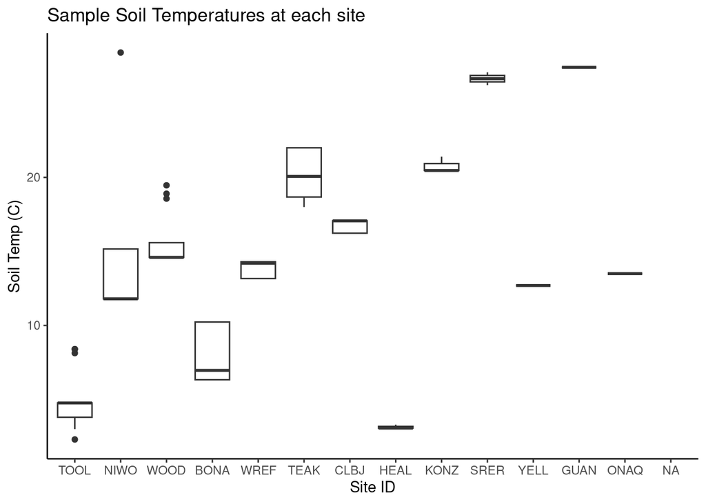

```r
NEON_chemistry_8 <-NEON_chemistry_7 %>%
  filter(str_detect(`GTDB-Tk Taxonomy Lineage`,"Gammaproteobacteria"))
NEON_chemistry_8 %>%
  ggplot(aes(x=fct_infreq(siteID), y=soilTemp))+geom_boxplot()+labs(title="Sample Soil Temperatures at each site", x="Site ID", y="Soil Temp (C)")+theme_classic()
```

## Exercise 9

Make a scatterplot of Ecosystem Subtype vs temperature. Use the Order as the color for the points.

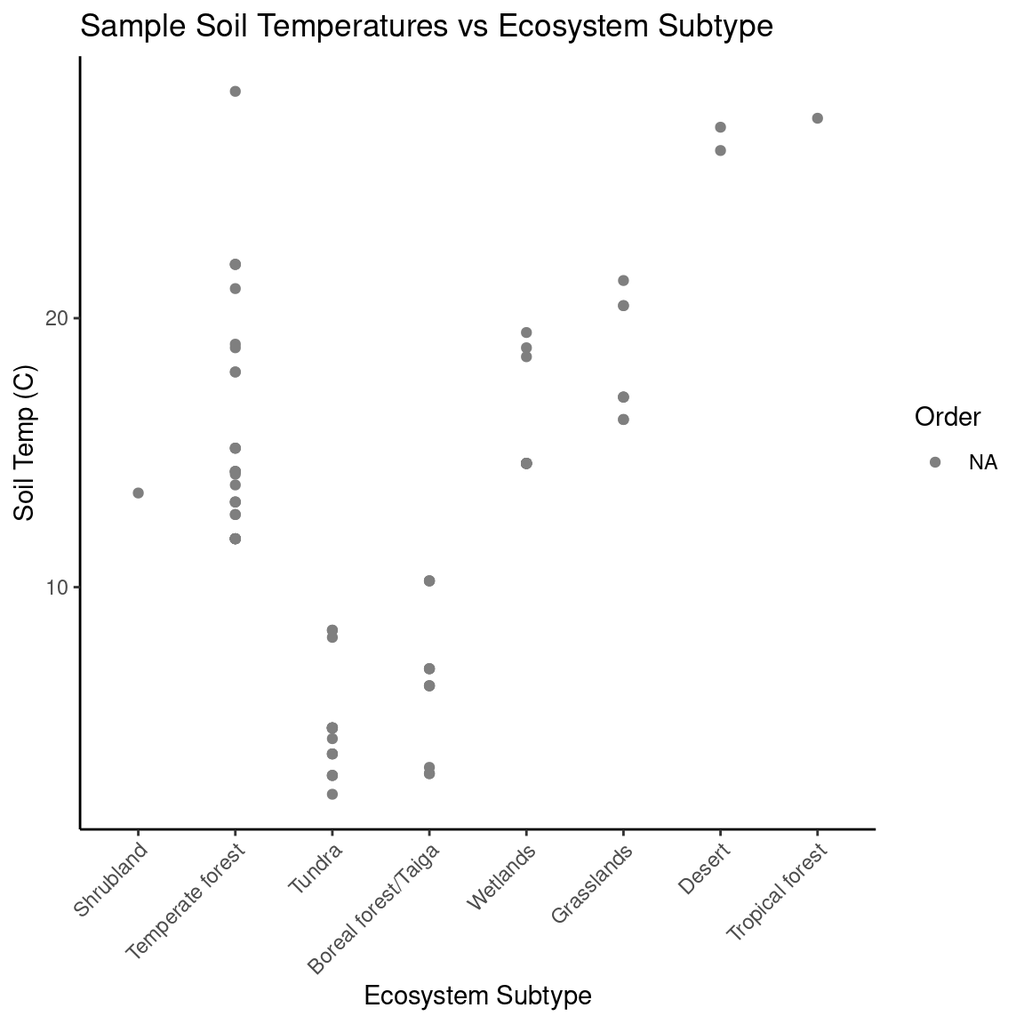

```r
NEON_chemistry_8 %>%
   ggplot(aes(x=fct_infreq(`Ecosystem Subtype`), y=soilTemp, color=Order))+geom_point()+labs(title="Sample Soil Temperatures vs Ecosystem Subtype", x="Ecosystem Subtype", y="Soil Temp (C)")+theme_classic()+theme(axis.text.x=element_text(angle=45, vjust=1, hjust=1))
```

## Exercise 10

Make a scatterplots of soilInCaClpH vs ncldClass (National Land Cover Database) terms. Use the Family as the color for the points.

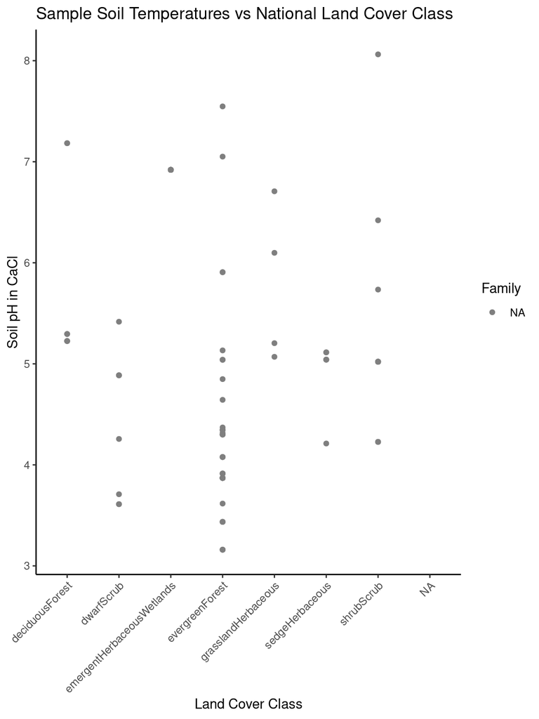

```r
NEON_chemistry_8 %>%
   ggplot(aes(x=`nlcdClass`,y=`soilInCaClpH`, color=Family))+geom_point()+labs(title="Sample Soil Temperatures vs National Land Cover Class", x="Land Cover Class", y="Soil pH in CaCl")+theme_classic()+theme(axis.text.x=element_text(angle=45, vjust=1, hjust=1))
```

## Exercise 11

Exploring the data is an important part of data analysis. Humans are great at visually recognizing patterns. Make 3 other graphs specific to your project.

```r
NEON_chemistry_11 <- NEON_chemistry_7 %>%
  filter(str_detect(siteID,"TOOL"))
NEON_chemistry_11
```

```
## # A tibble: 149 × 93
##    genomicsSa…¹ siteID plotID nlcdC…² decim…³ decim…⁴ eleva…⁵ collecti…⁶ horizon
##    <chr>        <chr>  <chr>  <chr>     <dbl>   <dbl>   <dbl> <date>     <chr>
##  1 TOOL_041-O-… TOOL   TOOL_… sedgeH…    68.7   -149.    827. 2021-08-03 O
##  2 TOOL_041-O-… TOOL   TOOL_… sedgeH…    68.7   -149.    827. 2021-08-03 O
##  3 TOOL_041-O-… TOOL   TOOL_… sedgeH…    68.7   -149.    827. 2021-08-03 O
##  4 TOOL_041-O-… TOOL   TOOL_… sedgeH…    68.7   -149.    827. 2021-08-03 O
##  5 TOOL_041-O-… TOOL   TOOL_… sedgeH…    68.7   -149.    827. 2021-08-03 O
##  6 TOOL_041-O-… TOOL   TOOL_… sedgeH…    68.7   -149.    827. 2021-08-03 O
##  7 TOOL_041-O-… TOOL   TOOL_… sedgeH…    68.7   -149.    827. 2021-08-03 O
##  8 TOOL_041-O-… TOOL   TOOL_… sedgeH…    68.7   -149.    827. 2021-08-03 O
##  9 TOOL_041-O-… TOOL   TOOL_… sedgeH…    68.7   -149.    827. 2021-08-03 O
## 10 TOOL_041-O-… TOOL   TOOL_… sedgeH…    68.7   -149.    827. 2021-08-03 O
## # … with 139 more rows, 84 more variables: soilTemp <dbl>, d15N <dbl>,
## #   organicd13C <dbl>, nitrogenPercent <dbl>, organicCPercent <dbl>,
## #   CNratio <dbl>, soilInWaterpH <dbl>, soilInCaClpH <dbl>, taxon_oid <dbl>,
## #   Domain.x <chr>, `Sequencing Status` <chr>, `Study Name` <chr>,
## #   Site.x <chr>, `Site ID.x` <chr>, Subplot.x <chr>, Layer.x <chr>,
## #   Date.x <chr>, `Sequencing Center` <chr>, `IMG Genome ID.x` <dbl>,
## #   `GOLD Study ID` <chr>, Ecosystem <chr>, `Ecosystem Category` <chr>, …
```

### Graph1

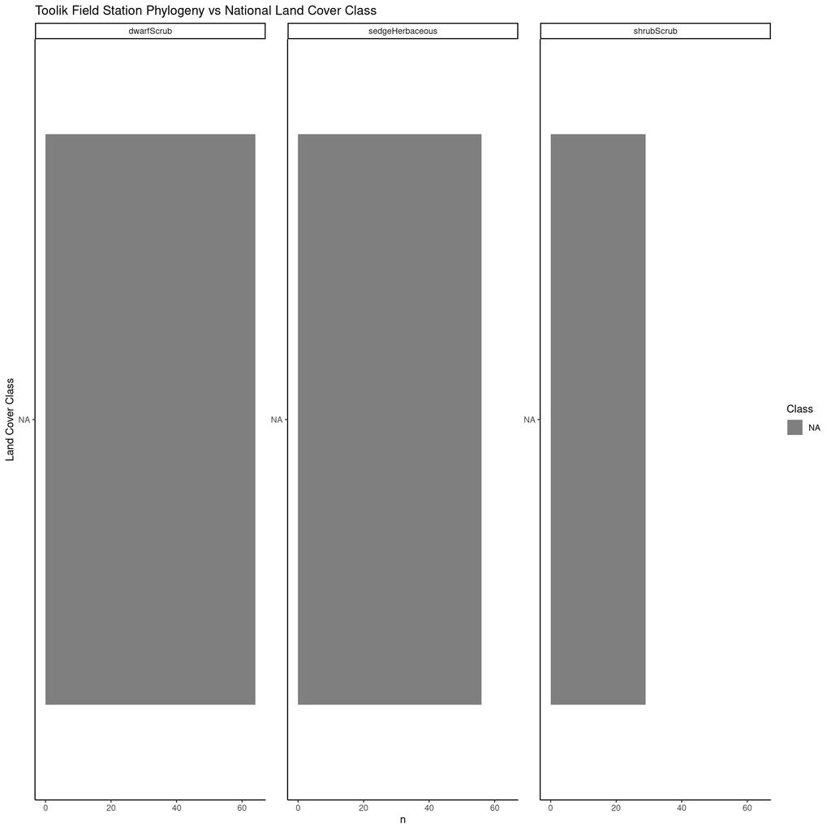

```r
NEON_chemistry_11 %>%
   ggplot(aes(x=`Phylum`, fill=Class))+geom_bar()+coord_flip()+facet_wrap(vars(nlcdClass), scales="free_y", ncol=3)+labs(title="Toolik Field Station Phylogeny vs National Land Cover Class", x="Land Cover Class", y="n")+theme_classic()
```

### Graph2

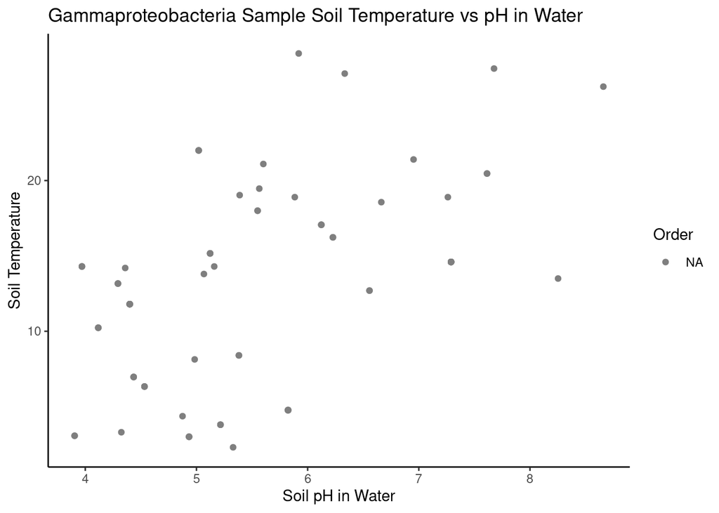

```r
NEON_chemistry_8 %>%
     ggplot(aes(y=`soilTemp`,x=`soilInWaterpH`, color=Order))+geom_point()+labs(title="Gammaproteobacteria Sample Soil Temperature vs pH in Water", y="Soil Temperature", x="Soil pH in Water")+theme_classic()
```

### Graph3

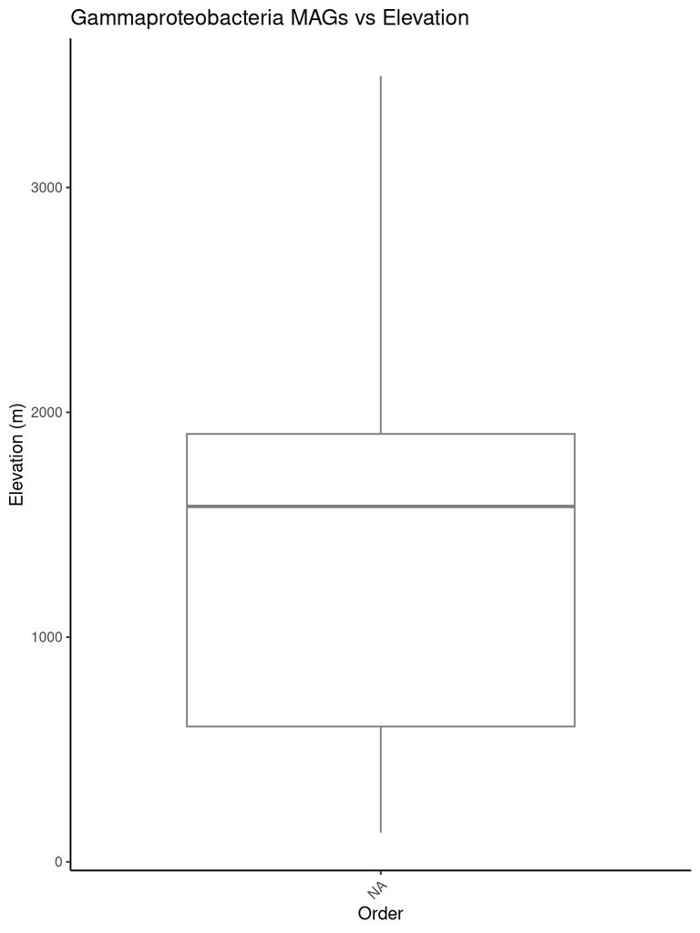

```r
NEON_chemistry_8 %>%
   ggplot(aes(y=`Elevation In Meters`, x=Order, color=Order))+geom_boxplot(show.legend = FALSE)+labs(title="Gammaproteobacteria MAGs vs Elevation", x="Order", y="Elevation (m)")+theme_classic()+theme(axis.text.x=element_text(angle=45, vjust=1, hjust=1))
```